# Практика в компании "Бюро национальной статистики - Департамент контроля качества данных"

## Казахстанский филиал Московского Государственного университета имени М. В. Ломоносова

### Практикант: Черкасов Борис Юрьевич

### 📊 Анализ данных по прибытию женщин (по ИИН мужчины) в СРН

### 🧾 Описание проекта

- Данный отчет посвящен исследованию демографических и регистрационных данных женщин, прибывших и зарегистрированных в системе регистрации населения (СРН) по ИИН мужчины.

### 🧩 Цели анализа:

- Исследовать возрастное распределение зарегистрированных женщин
- Проанализировать причины регистрации (по кодам)
- Определить топ-страны прибытия
- Построить распределение по годам рождения
- Определить долю живых и умерших
- Найти дополнительные инсайты через визуализацию и статистический анализ

### 📁 Структура данных:

- Набор данных содержит следующие ключевые поля:
- дата_рождения — дата рождения
- возраст_на_момент_под_заяв — возраст на момент подачи заявления
- код_причина_регистрации — код причины регистрации
- код_страны_прибытия — страна прибытия
- death_date — дата смерти (если есть)

### 🛠 Используемые инструменты:

- pandas для работы с таблицей данных
- matplotlib и seaborn для построения визуализаций
- Визуальный анализ с подробными комментариями

| Название столбца | Назначение / Идеи анализа |
| --- | --- |
| `дата_рождения` | 📅 Гистограмма по годам рождения, средний возраст |
| `возраст_на_момент_под_заяв` | 📊 Гистограмма и boxplot возрастов |
| `код_причина_регистрации` | 📌 Barplot или pie chart причин |
| `код_страны_прибытия` | 🌍 Топ стран прибытия, barplot |
| `death_date` | ⚰️ Доля умерших/живых — столбчатая диаграмма |
| `дата_регистрации` (если есть) | 🗓 Распределение по годам регистрации |
| `дата_выписки` (если есть) | ⏳ Анализ длительности пребывания |
| `гражданство` | 🌐 Топ гражданств — barplot |
| `регион_прибытия` или `адрес` | 🗺 Географическое распределение (если есть) |
| `пол` | ⚥ Если встречается — распределение по полу (уже известно, что "женщины") |

```python
# Подключение библиотек для анализа
import pandas as pd
import matplotlib.pyplot as plt
import seaborn as sns
import numpy as np

import plotly.graph_objects as go
import plotly.express as px
import geopandas as gp

import missingno as msno
from scipy.stats import zscore
import warnings
warnings.filterwarnings("ignore")
```

```python
import plotly.io as pio
pio.renderers.default = 'browser'  # откроется в браузере
```

```python
pio.renderers  # покажет список доступных
```

```
Renderers configuration
-----------------------
    Default renderer: 'browser'
    Available renderers:
        ['plotly_mimetype', 'jupyterlab', 'nteract', 'vscode',
         'notebook', 'notebook_connected', 'kaggle', 'azure', 'colab',
         'cocalc', 'databricks', 'json', 'png', 'jpeg', 'jpg', 'svg',
         'pdf', 'browser', 'firefox', 'chrome', 'chromium', 'iframe',
         'iframe_connected', 'sphinx_gallery', 'sphinx_gallery_png']
```

```python
# Настройки визуализации
sns.set(style="whitegrid")
plt.rcParams['figure.figsize'] = (10, 5)

# Загрузка Excel-файла
file_path = "./РПДРН_ГБД_ФЛ/Т8_РПДРН_прибытие_по иин женщина а по гендеру мужчина  в СРН 2.xlsx"
xls = pd.ExcelFile(file_path)
df = xls.parse('Export Worksheet')
df.columns = [col.lower() for col in df.columns]

# Посмотрим на данные
df.head()
```

|  | иин | номер_удл | дата_удл | национальность | пол | пол_1 | возраст_на_момент_под_заяв | дата_рождения | код_причина_регистрации | код_страны_прибытия | ... | death_date | bp_address | dp_address | nationality | citizenship | status | email | nationality_ds | gender | gender_name |
| --- | --- | --- | --- | --- | --- | --- | --- | --- | --- | --- | --- | --- | --- | --- | --- | --- | --- | --- | --- | --- | --- |
| 0 | 90619650027 | NaN | NaN | 999 | M | Мужчина | 15.011 | 19.06.09 | 4 | 398 | ... | NaT | 13597694 | NaN | 39365 | 19718361 | 1 | NaN | 2.0 | 43036 | Мужчина |
| 1 | 680218450028 | 56521600.0 | 17.10.23 | 5 | M | Мужчина | 56.051 | 18.02.68 | 4 | 398 | ... | NaT | 227098 | NaN | 39365 | 19718361 | 1 | NaN | NaN | 43036 | Мужчина |
| 2 | 80717653756 | 58825506.0 | 21.08.24 | 5 | M | Мужчина | 16.009 | 17.07.08 | 2 | 398 | ... | NaT | 227056 | NaN | 39365 | 19718361 | 1 | NaN | NaN | 43036 | Мужчина |
| 3 | 90303651245 | 60251458.0 | 09.04.25 | 5 | M | Мужчина | 15.032 | 03.03.09 | 4 | 398 | ... | NaT | 226473 | NaN | 39365 | 19718361 | 1 | NaN | NaN | 43036 | Мужчина |
| 4 | 522601520 | 54516407.0 | 02.10.23 | 5 | M | Мужчина | 23.960 | 22.05.00 | 1 | 398 | ... | NaT | 13650667 | NaN | 39365 | 19718361 | 1 | NaN | NaN | 43036 | Мужчина |

5 rows × 54 columns

```python
# Какие есть столбцы
df.columns
```

```
Index(['иин', 'номер_удл', 'дата_удл', 'национальность', 'пол', 'пол_1',
       'возраст_на_момент_под_заяв', 'дата_рождения',
       'код_причина_регистрации', 'код_страны_прибытия', 'код_область_м_ж',
       'код_район_м_ж', 'нас_пункт_м_ж', 'улица_м_ж', 'дом_м_ж', 'корпус_м_ж',
       'кв_м_ж', 'рка_м_ж', 'дата_прибытия', 'код_преж_страна',
       'код_преж_область_м_ж', 'код_преж_район_м_ж', 'преж_нас_пункт_м_ж',
       'преж_улица_м_ж', 'преж_дом_м_ж', 'преж_корпус_м_ж', 'преж_кв_м_ж',
       'преж_рка_м_ж', 'дата_выбытия', 'код_цель_прибытия',
       'код_семейное_положение', 'код_уровень_образование',
       'код_спец_по_образованию', 'код_положение_в_занятости', 'система',
       'тип_услуги', 'id', 'source_id', 'person_id', 'iin', 'l_name', 'f_name',
       'm_name', 'birth_date', 'death_date', 'bp_address', 'dp_address',
       'nationality', 'citizenship', 'status', 'email', 'nationality_ds',
       'gender', 'gender_name'],
      dtype='object')
```

#### Предварительный анализ

```python
# Посмотрим на столбцы
df.info()
```

```
<class 'pandas.core.frame.DataFrame'>
RangeIndex: 1413 entries, 0 to 1412
Data columns (total 54 columns):
 #   Column                      Non-Null Count  Dtype
---  ------                      --------------  -----
 0   иин                         1413 non-null   int64
 1   номер_удл                   1182 non-null   float64
 2   дата_удл                    1182 non-null   object
 3   национальность              1413 non-null   int64
 4   пол                         1413 non-null   object
 5   пол_1                       1413 non-null   object
 6   возраст_на_момент_под_заяв  1413 non-null   float64
 7   дата_рождения               1413 non-null   object
 8   код_причина_регистрации     1413 non-null   int64
 9   код_страны_прибытия         1413 non-null   int64
```

[output cut: 46 more lines]

```python
# Посмотрим на числовые характеристики
df.describe()
```

|  | иин | номер_удл | национальность | возраст_на_момент_под_заяв | код_причина_регистрации | код_страны_прибытия | код_область_м_ж | код_район_м_ж | рка_м_ж | код_преж_страна | ... | birth_date | death_date | bp_address | dp_address | nationality | citizenship | status | email | nationality_ds | gender |
| --- | --- | --- | --- | --- | --- | --- | --- | --- | --- | --- | --- | --- | --- | --- | --- | --- | --- | --- | --- | --- | --- |
| count | 1.413000e+03 | 1.182000e+03 | 1413.000000 | 1413.000000 | 1413.000000 | 1413.0 | 1413.000000 | 1413.000000 | 1.413000e+03 | 1385.000000 | ... | 1413 | 6 | 1.413000e+03 | 0.0 | 1413.000000 | 1.413000e+03 | 1413.000000 | 0.0 | 127.000000 | 1413.000000 |
| mean | 3.302224e+11 | 5.130228e+07 | 105.149328 | 28.097338 | 2.745223 | 398.0 | 1929.704883 | 451.143666 | 6.948552e+14 | 398.884477 | ... | 1997-06-14 05:59:44.713375744 | 2024-12-07 20:00:00 | 3.165599e+06 | NaN | 39369.627742 | 1.971836e+07 | 1.006369 | NaN | 2.086614 | 43036.004954 |
| min | 1.276015e+08 | 1.258282e+07 | 1.000000 | 1.010000 | 1.000000 | 398.0 | 1902.000000 | 68.000000 | 2.013000e+14 | 398.000000 | ... | 1950-04-09 00:00:00 | 2024-06-15 00:00:00 | 2.264640e+05 | NaN | 39361.000000 | 1.971836e+07 | 0.000000 | NaN | 1.000000 | 43036.000000 |
| 25% | 8.031765e+10 | 4.558824e+07 | 5.000000 | 15.991000 | 2.000000 | 398.0 | 1910.000000 | 153.000000 | 2.013003e+14 | 398.000000 | ... | 1981-10-04 00:00:00 | 2024-10-02 18:00:00 | 2.266580e+05 | NaN | 39365.000000 | 1.971836e+07 | 1.000000 | NaN | 2.000000 | 43036.000000 |
| 50% | 9.061965e+10 | 5.529111e+07 | 5.000000 | 17.081000 | 3.000000 | 398.0 | 1919.000000 | 316.000000 | 2.024000e+14 | 398.000000 | ... | 2007-07-06 00:00:00 | 2024-12-10 00:00:00 | 2.285040e+05 | NaN | 39365.000000 | 1.971836e+07 | 1.000000 | NaN | 2.000000 | 43036.000000 |
| 75% | 7.006104e+11 | 5.803120e+07 | 5.000000 | 43.020000 | 4.000000 | 398.0 | 1959.000000 | 746.000000 | 1.201400e+15 | 398.000000 | ... | 2008-10-10 00:00:00 | 2025-03-23 12:00:00 | 3.550510e+05 | NaN | 39365.000000 | 1.971836e+07 | 1.000000 | NaN | 2.000000 | 43036.000000 |
| max | 9.912265e+11 | 6.033767e+07 | 999.000000 | 90.921000 | 5.000000 | 398.0 | 1963.000000 | 797.000000 | 1.202400e+15 | 643.000000 | ... | 2049-05-15 00:00:00 | 2025-04-07 00:00:00 | 2.925456e+07 | NaN | 39491.000000 | 1.971843e+07 | 9.000000 | NaN | 4.000000 | 43037.000000 |
| std | 3.456234e+11 | 9.007173e+06 | 292.029222 | 17.311337 | 0.997263 | 0.0 | 21.456622 | 287.055899 | 5.001846e+14 | 14.699335 | ... | NaN | NaN | 5.559227e+06 | NaN | 22.511851 | 4.683459e+00 | 0.250979 | NaN | 0.488334 | 0.070235 |

8 rows × 32 columns

```python
# Посмотрим на пропуски
df.isna().sum()
```

```
иин                              0
номер_удл                      231
дата_удл                       231
национальность                   0
пол                              0
пол_1                            0
возраст_на_момент_под_заяв       0
дата_рождения                    0
код_причина_регистрации          0
код_страны_прибытия              0
код_область_м_ж                  0
код_район_м_ж                    0
нас_пункт_м_ж                  860
улица_м_ж                        1
дом_м_ж                          0
корпус_м_ж                    1366
кв_м_ж                         716
рка_м_ж                          0
дата_прибытия                    0
код_преж_страна                 28
код_преж_область_м_ж            28
код_преж_район_м_ж              27
преж_нас_пункт_м_ж             801
преж_улица_м_ж                  58
преж_дом_м_ж                    65
преж_корпус_м_ж               1378
преж_кв_м_ж                    776
преж_рка_м_ж                    81
дата_выбытия                  1382
код_цель_прибытия                0
код_семейное_положение         293
код_уровень_образование        293
код_спец_по_образованию        437
код_положение_в_занятости      293
система                          0
тип_услуги                       0
id                               0
source_id                        0
person_id                        0
iin                              0
l_name                           0
f_name                           0
m_name                         134
birth_date                       0
death_date                    1407
bp_address                       0
dp_address                    1413
nationality                      0
citizenship                      0
status                           0
email                         1413
nationality_ds                1286
gender                           0
gender_name                      0
dtype: int64
```

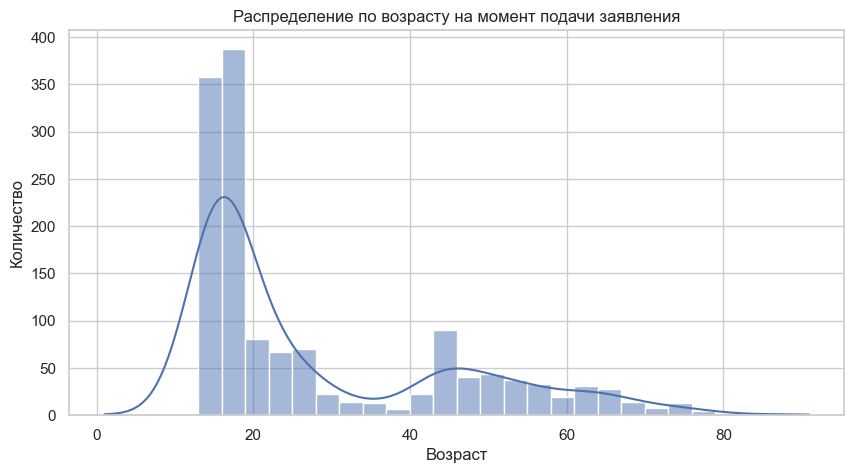

```python
# Распределение по возрасту
sns.histplot(df['возраст_на_момент_под_заяв'], bins=30, kde=True)
plt.title('Распределение по возрасту на момент подачи заявления')
plt.xlabel('Возраст')
plt.ylabel('Количество')
plt.show()
```

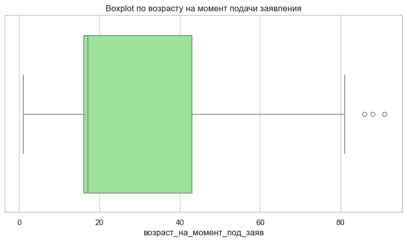

```python
# Посмотрим, есть ли аномалии
sns.boxplot(x=df['возраст_на_момент_под_заяв'], color='lightgreen')
plt.title("Boxplot по возрасту на момент подачи заявления")
plt.show()
```

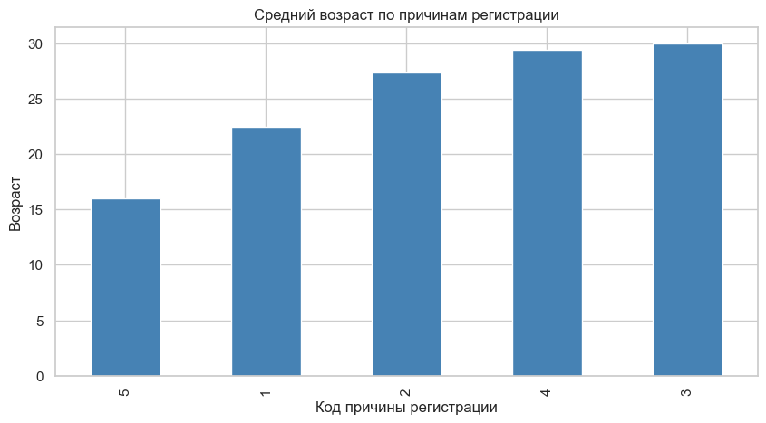

```python
# Посмотрим на возраст по причинам регистрации
df.groupby('код_причина_регистрации')['возраст_на_момент_под_заяв'].mean().sort_values().plot(kind='bar', color='steelblue')
plt.title('Средний возраст по причинам регистрации')
plt.ylabel('Возраст')
plt.xlabel('Код причины регистрации')
plt.show()
```

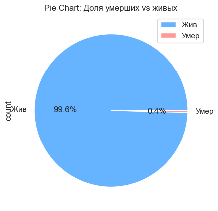

```python
df['status'] = df['death_date'].isna().map({True: 'Жив', False: 'Умер'})
df['status'].value_counts().plot(kind='pie', autopct='%1.1f%%', colors=['#66b3ff', '#ff9999'])
plt.title("Pie Chart: Доля умерших vs живых")
plt.legend(loc='best')
plt.show()
```

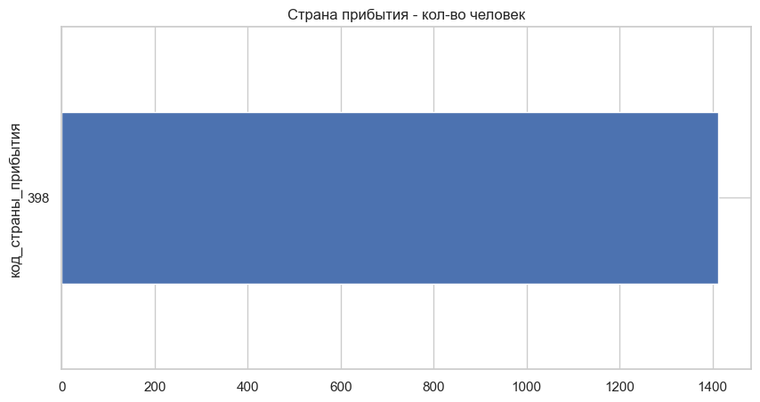

```python
# Страна прибытия единственная - закодирована под кодом 398
df['код_страны_прибытия'].value_counts().head(10).plot(kind='barh')
plt.title("Страна прибытия - кол-во человек")
plt.show()
```

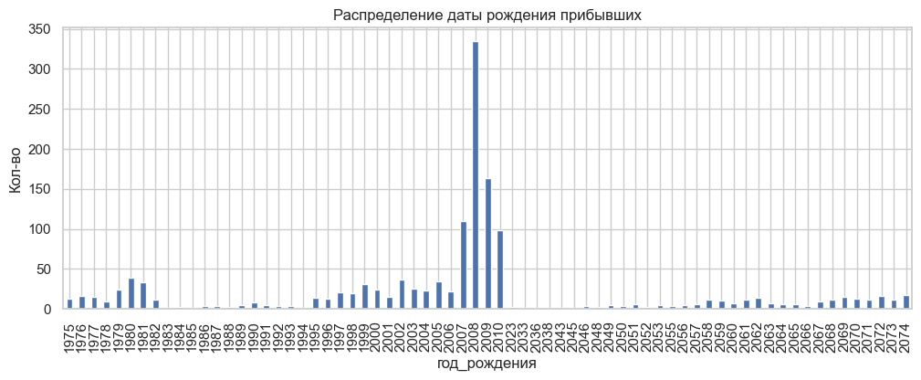

```python
# Дата рождения
plt.figure(figsize=(12, 6))
df['год_рождения'] = pd.to_datetime(df['дата_рождения'], errors='coerce').dt.year
df['год_рождения'].value_counts().sort_index().plot(kind='bar', figsize=(12,4))
plt.ylabel("Кол-во")
plt.title("Распределение даты рождения прибывших")
plt.show()
```

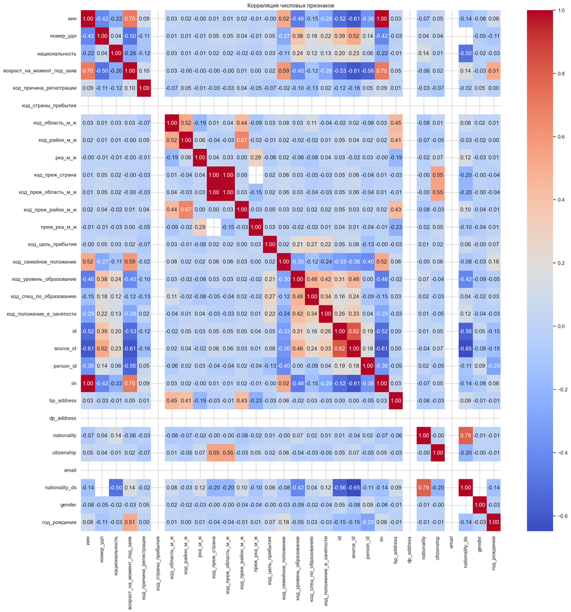

```python
# Посмотрим на корреляцию переменных
plt.figure(figsize=(20, 20))
sns.heatmap(df.select_dtypes(include='number').corr(), annot=True, cmap='coolwarm', fmt='.2f')
plt.title('Корреляция числовых признаков')
plt.show()
```

```python
df.columns
```

```
Index(['иин', 'номер_удл', 'дата_удл', 'национальность', 'пол', 'пол_1',
       'возраст_на_момент_под_заяв', 'дата_рождения',
       'код_причина_регистрации', 'код_страны_прибытия', 'код_область_м_ж',
       'код_район_м_ж', 'нас_пункт_м_ж', 'улица_м_ж', 'дом_м_ж', 'корпус_м_ж',
       'кв_м_ж', 'рка_м_ж', 'дата_прибытия', 'код_преж_страна',
       'код_преж_область_м_ж', 'код_преж_район_м_ж', 'преж_нас_пункт_м_ж',
       'преж_улица_м_ж', 'преж_дом_м_ж', 'преж_корпус_м_ж', 'преж_кв_м_ж',
       'преж_рка_м_ж', 'дата_выбытия', 'код_цель_прибытия',
       'код_семейное_положение', 'код_уровень_образование',
       'код_спец_по_образованию', 'код_положение_в_занятости', 'система',
       'тип_услуги', 'id', 'source_id', 'person_id', 'iin', 'l_name', 'f_name',
       'm_name', 'birth_date', 'death_date', 'bp_address', 'dp_address',
       'nationality', 'citizenship', 'status', 'email', 'nationality_ds',
       'gender', 'gender_name', 'год_рождения'],
      dtype='object')
```

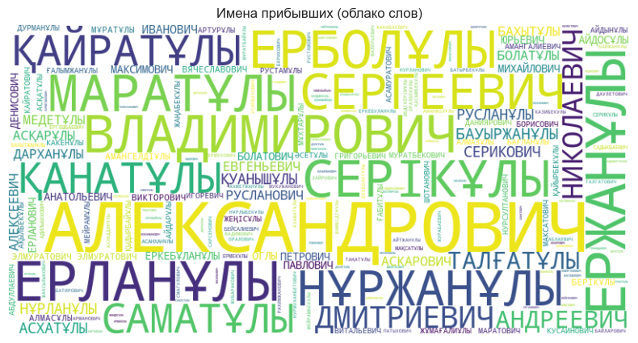

```python
# Облако слов
df = xls.parse('Export Worksheet')
df.columns = [col.lower() for col in df.columns]

from wordcloud import WordCloud

text = " ".join(df["m_name"].dropna().astype(str))
wordcloud = WordCloud(width=800, height=400, background_color='white').generate(text)

plt.figure(figsize=(10, 5))
plt.imshow(wordcloud, interpolation="bilinear")
plt.axis("off")
plt.title("Имена прибывших (облако слов)")
plt.show()
```

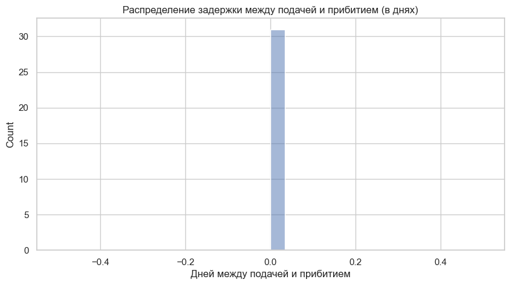

```python
# Время между подачей и прибитием
df["дата_прибытия"] = pd.to_datetime(df["дата_прибытия"], errors="coerce")
df["дата_выбытия"] = pd.to_datetime(df["дата_выбытия"], errors="coerce")

df["delay_days"] = (df["дата_прибытия"] - df["дата_выбытия"]).dt.days
sns.histplot(df["delay_days"].dropna(), bins=30, kde=True)
plt.title("Распределение задержки между подачей и прибитием (в днях)")
plt.xlabel("Дней между подачей и прибитием")
plt.show()
```

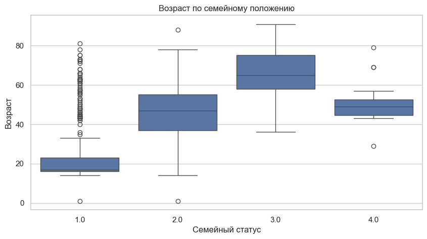

```python
# Проверка на аномалии по семейному статусу
sns.boxplot(x="код_семейное_положение", y="возраст_на_момент_под_заяв", data=df)
plt.title("Возраст по семейному положению")
plt.xlabel("Семейный статус")
plt.ylabel("Возраст")
plt.show()
```

```python
df.info()
```

```
<class 'pandas.core.frame.DataFrame'>
RangeIndex: 1413 entries, 0 to 1412
Data columns (total 55 columns):
 #   Column                      Non-Null Count  Dtype
---  ------                      --------------  -----
 0   иин                         1413 non-null   int64
 1   номер_удл                   1182 non-null   float64
 2   дата_удл                    1182 non-null   object
 3   национальность              1413 non-null   int64
 4   пол                         1413 non-null   object
 5   пол_1                       1413 non-null   object
 6   возраст_на_момент_под_заяв  1413 non-null   float64
 7   дата_рождения               1413 non-null   object
 8   код_причина_регистрации     1413 non-null   int64
 9   код_страны_прибытия         1413 non-null   int64
```

[output cut: 47 more lines]

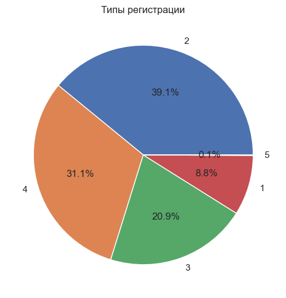

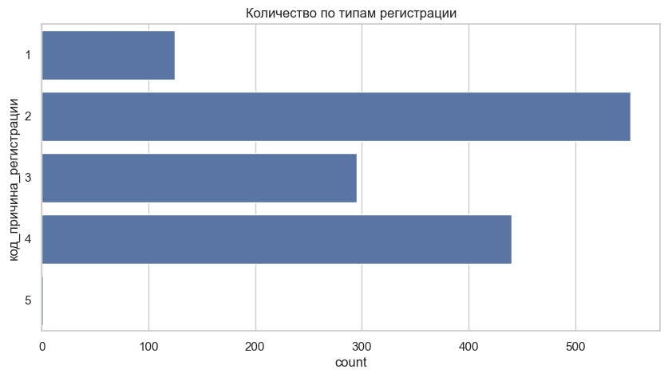

```python
reg_counts = df["код_причина_регистрации"].value_counts()

# Pie Chart
reg_counts.plot.pie(autopct='%1.1f%%', figsize=(6, 6), title="Типы регистрации")
plt.ylabel("")
plt.show()

# Bar Chart
sns.countplot(y="код_причина_регистрации", data=df)
plt.title("Количество по типам регистрации")
plt.show()
```

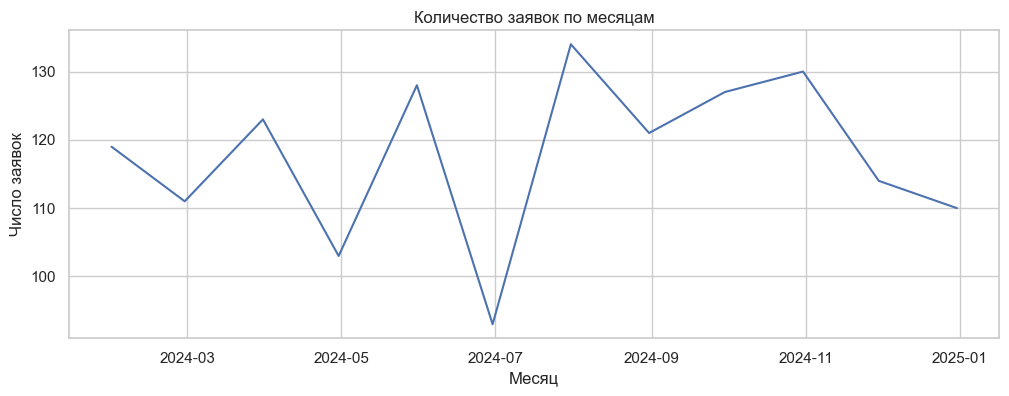

```python
df['дата_прибытия'] = pd.to_datetime(df['дата_прибытия'])
monthly_counts = df.resample('M', on='дата_прибытия').size()

plt.figure(figsize=(12, 4))
sns.lineplot(x=monthly_counts.index, y=monthly_counts.values)
plt.title("Количество заявок по месяцам")
plt.xlabel("Месяц")
plt.ylabel("Число заявок")
plt.grid(True)
plt.show()
```

Нижний код можно запустить, чтобы получить интерактивный график на веб-странице, ниже прикреплено фото графика.

```python
from plotly.colors import DEFAULT_PLOTLY_COLORS

# Пример: 'национальность', 'цель_прибытия', 'тип_регистрации'
df_sankey = df[["национальность", "код_цель_прибытия", "код_причина_регистрации"]].dropna()

# Подготовка узлов
all_nodes = list(pd.unique(df_sankey.values.ravel()))
node_indices = {k: v for v, k in enumerate(all_nodes)}

# Создание потоков
links = df_sankey.groupby(["национальность", "код_цель_прибытия"]).size().reset_index(name="value")
links["source"] = links["национальность"].map(node_indices)
links["target"] = links["код_цель_прибытия"].map(node_indices)

# Вторая часть: цель → тип
links2 = df_sankey.groupby(["код_цель_прибытия", "код_причина_регистрации"]).size().reset_index(name="value")
links2["source"] = links2["код_цель_прибытия"].map(node_indices)
links2["target"] = links2["код_причина_регистрации"].map(node_indices)

# Объединение
all_links = pd.concat([links, links2], ignore_index=True)

fig = go.Figure(data=[go.Sankey(
    node=dict(label=all_nodes, pad=15, thickness=15, color=DEFAULT_PLOTLY_COLORS),
    link=dict(source=all_links["source"], target=all_links["target"], value=all_links["value"])
)])
fig.update_layout(title_text="Sankey диаграмма", font_size=10)
fig.show()
```

[figure not shown]

```python
# Интеракивный график страны подачи заявок - но у нас одна страна
country_counts = df["национальность"].value_counts().reset_index()
country_counts.columns = ["country", "count"]

fig = px.choropleth(country_counts,
                    locations="country",
                    locationmode="country names",
                    color="count",
                    title="Количество заявок по странам",
                    color_continuous_scale="Viridis")
fig.show()
```

#### Анализ пропусков

```
=== Пропущенные значения (%): ===
email                        100.000000
dp_address                   100.000000
death_date                    99.575372
дата_выбытия                  97.806086
delay_days                    97.806086
преж_корпус_м_ж               97.523001
корпус_м_ж                    96.673744
nationality_ds                91.012031
нас_пункт_м_ж                 60.863411
преж_нас_пункт_м_ж            56.687898
преж_кв_м_ж                   54.918613
кв_м_ж                        50.672328
код_спец_по_образованию       30.927105
код_семейное_положение        20.736023
код_положение_в_занятости     20.736023
код_уровень_образование       20.736023
номер_удл                     16.348195
дата_удл                      16.348195
m_name                         9.483369
преж_рка_м_ж                   5.732484
преж_дом_м_ж                   4.600142
преж_улица_м_ж                 4.104742
код_преж_страна                1.981599
код_преж_область_м_ж           1.981599
код_преж_район_м_ж             1.910828
улица_м_ж                      0.070771
dtype: float64
```

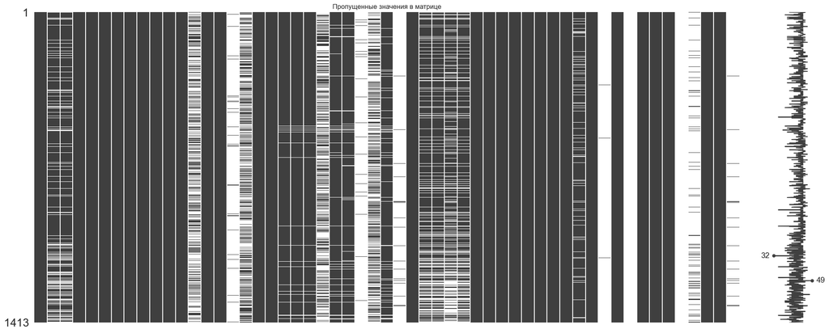

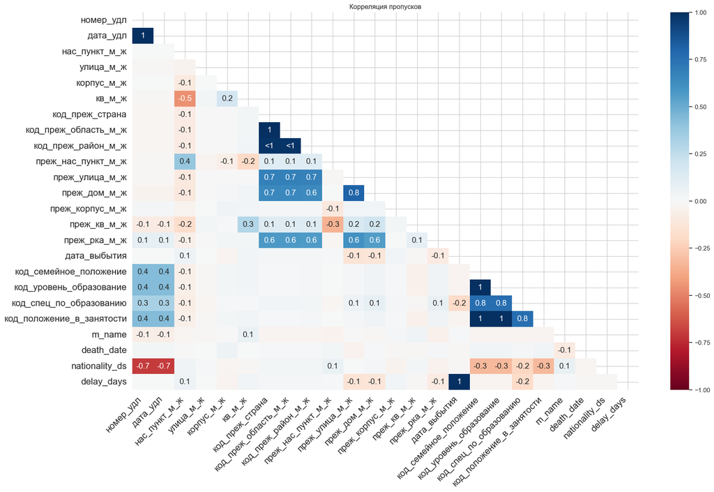

```python
# -----------------------------
# Анализ пропусков
# -----------------------------
print("=== Пропущенные значения (%): ===")
missing_percent = df.isnull().mean() * 100
print(missing_percent[missing_percent > 0].sort_values(ascending=False))

# Визуализация пропусков
msno.matrix(df)
plt.title("Пропущенные значения в матрице")
plt.show()

msno.heatmap(df)
plt.title("Корреляция пропусков")
plt.show()
```

```
Количество выбросов по возрасту (z > 3): 4
```

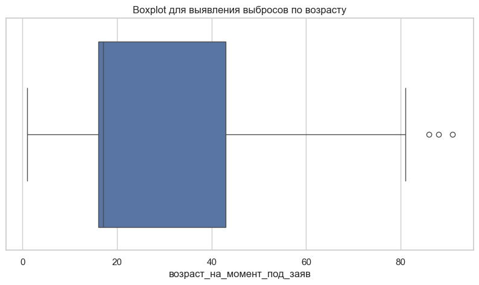

```python
# -----------------------------
# Анализ выбросов по возрасту
# -----------------------------
df['z_age'] = zscore(df['возраст_на_момент_под_заяв'].fillna(df['возраст_на_момент_под_заяв'].median()))
outliers = df[df['z_age'].abs() > 3]
print(f"Количество выбросов по возрасту (z > 3): {len(outliers)}")

sns.boxplot(x=df['возраст_на_момент_под_заяв'])
plt.title('Boxplot для выявления выбросов по возрасту')
plt.show()
```

```python
# Проверка на несоответствие - базовая
df[df['возраст_на_момент_под_заяв'] > 100]
```

|  | иин | номер_удл | дата_удл | национальность | пол | пол_1 | возраст_на_момент_под_заяв | дата_рождения | код_причина_регистрации | код_страны_прибытия | ... | dp_address | nationality | citizenship | status | email | nationality_ds | gender | gender_name | delay_days | z_age |
| --- | --- | --- | --- | --- | --- | --- | --- | --- | --- | --- | --- | --- | --- | --- | --- | --- | --- | --- | --- | --- | --- |

0 rows × 56 columns

```python
# Общий подсчёт пропущенных значений
missing_counts = df.isnull().sum()
missing_percent = (missing_counts / len(df)) * 100

# Объединённый DataFrame для удобства
missing_df = pd.DataFrame({
    'Количество пропусков': missing_counts,
    'Процент пропусков (%)': missing_percent
})

# Фильтруем только столбцы с пропусками
missing_df = missing_df[missing_df['Количество пропусков'] > 0].sort_values(by='Процент пропусков (%)', ascending=False)

# Вывод
missing_df.style.background_gradient(cmap='Reds').format({'Процент пропусков (%)': "{:.2f}"})
```

|  | Количество пропусков | Процент пропусков (%) |
| --- | --- | --- |
| email | 1413 | 100.00 |
| dp_address | 1413 | 100.00 |
| death_date | 1407 | 99.58 |
| дата_выбытия | 1382 | 97.81 |
| delay_days | 1382 | 97.81 |
| преж_корпус_м_ж | 1378 | 97.52 |
| корпус_м_ж | 1366 | 96.67 |
| nationality_ds | 1286 | 91.01 |
| нас_пункт_м_ж | 860 | 60.86 |
| преж_нас_пункт_м_ж | 801 | 56.69 |
| преж_кв_м_ж | 776 | 54.92 |
| кв_м_ж | 716 | 50.67 |
| код_спец_по_образованию | 437 | 30.93 |
| код_семейное_положение | 293 | 20.74 |
| код_положение_в_занятости | 293 | 20.74 |
| код_уровень_образование | 293 | 20.74 |
| номер_удл | 231 | 16.35 |
| дата_удл | 231 | 16.35 |
| m_name | 134 | 9.48 |
| преж_рка_м_ж | 81 | 5.73 |
| преж_дом_м_ж | 65 | 4.60 |
| преж_улица_м_ж | 58 | 4.10 |
| код_преж_страна | 28 | 1.98 |
| код_преж_область_м_ж | 28 | 1.98 |
| код_преж_район_м_ж | 27 | 1.91 |
| улица_м_ж | 1 | 0.07 |

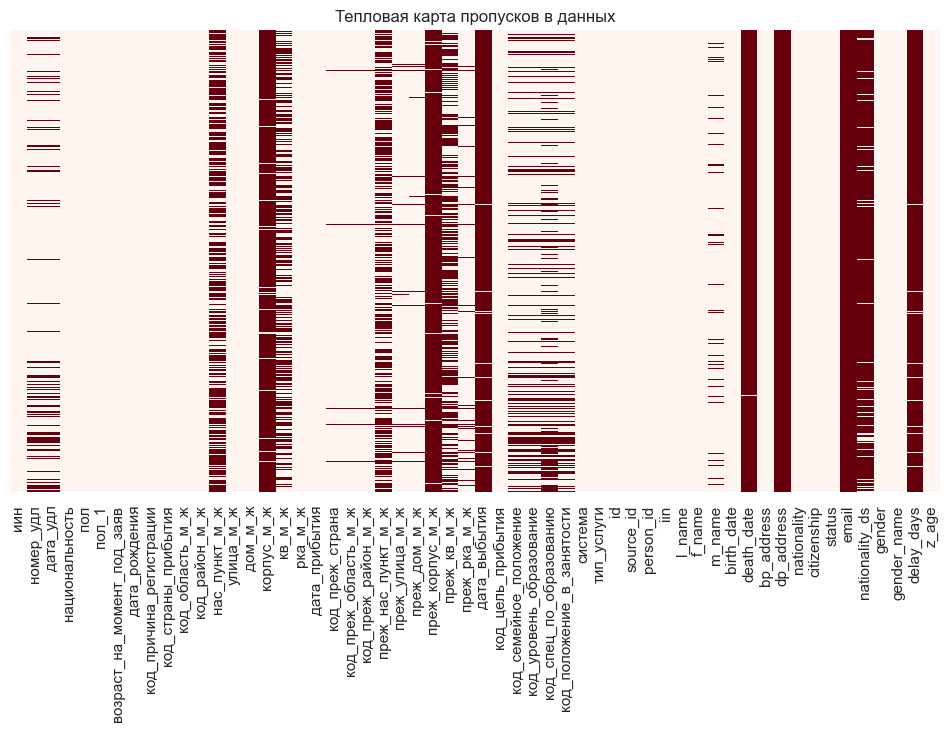

```python
# Визуализация пропусков
plt.figure(figsize=(12, 6))
sns.heatmap(df.isnull(), cbar=False, yticklabels=False, cmap='Reds')
plt.title('Тепловая карта пропусков в данных')
plt.show()
```

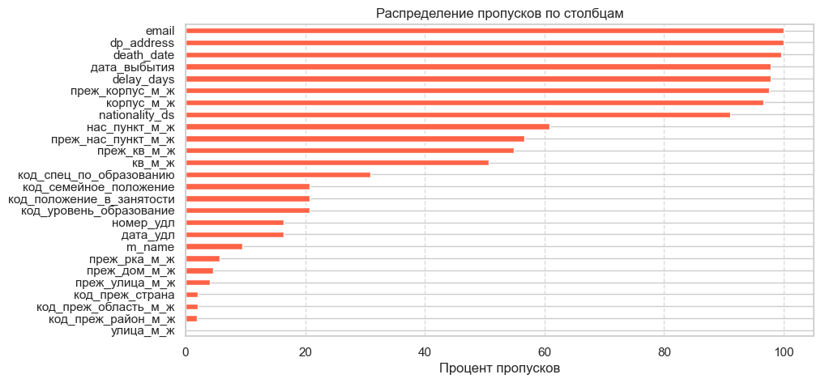

```python
# Barchart пропусков
plt.figure(figsize=(10, 5))
missing_df['Процент пропусков (%)'].plot(kind='barh', color='tomato')
plt.xlabel("Процент пропусков")
plt.title("Распределение пропусков по столбцам")
plt.gca().invert_yaxis()
plt.grid(axis='x', linestyle='--', alpha=0.7)
plt.show()
```

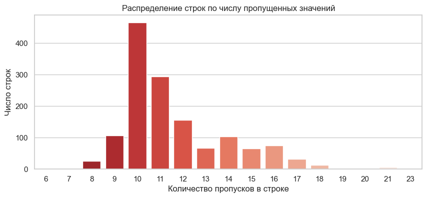

```python
# Распределенеи строк по числу пропусков
df['Кол-во пропусков в строке'] = df.isnull().sum(axis=1)
row_missing_stats = df['Кол-во пропусков в строке'].value_counts().sort_index()

plt.figure(figsize=(10, 4))
sns.barplot(x=row_missing_stats.index, y=row_missing_stats.values, palette='Reds_r')
plt.xlabel('Количество пропусков в строке')
plt.ylabel('Число строк')
plt.title('Распределение строк по числу пропущенных значений')
plt.show()

# Удалим временный столбец
df.drop(columns='Кол-во пропусков в строке', inplace=True)
```